# Reply Tools AB Test Report

Megan Neisler

Data Scientist, Wikimedia Foundation

26 March 2021

# Introduction

The Wikimedia Foundation’s [Editing team](https://www.mediawiki.org/wiki/Editing_team#:~:text=The%20Editing%20team%20is%20the,tools%20like%20TemplateData%20and%20Citoid.) is working to improve how contributors communicate on Wikipedia using talk pages through a series of incremental improvements that will be released over time.

The team ran an AB test of the Reply Tool from 11 February 2021 through 10 March 2021 to assess the efficacy of this new feature, specifically on Junior Contributors (defined as having under 100 cumulative edits). The test included logged-in users that had not used the Reply Tool before (defined as users whose `discussiontools-editmode` preference is empty) and attempted an edit at one of the 22 participating Wikipedias (see full list of [participating Wikipedias](https://www.mediawiki.org/wiki/Talk_pages_project#Active_initiatives)) during the duration of the AB test. During this test, 50% of all logged-in users at the Wikipedias included in the test had the Reply tool automatically enabled, and 50% did not. Users at these Wikipedias were still able to turn the tool on or off the tool in Special:Preferences.

You can find more information about features of this tool and project updates on the [project page](https://www.mediawiki.org/wiki/Talk_pages_project/Replying).

# Purpose

The primary goal of the AB test was to test the hypothesis that using the reply tool will increase the likelihood of a Junior Contributor publishing a comment they start without a significant increase in disruption.

For this analysis, our key performance indicator to evaluate the impact of the tool is comment completion rate, which we define as:

**Of the contributors who click the [ reply ] link, what percent of contributors successfully publish the comment they were drafting at least once during the reviewed timeframe.**

We will assess disruption by looking at the percent of comments made to talk pages that are reverted within 48 hours and the percent of contributors who are blocked after making an edit to a talk page.

The results of this analysis will be used to determine if the Reply Tool should be deployed as default to all Wiki projects, as an opt-out user preference. Please see further details about the hypotheses, key performance indicators, and decision scenarios in the [task description](https://phabricator.wikimedia.org/T252057).

# Methodology

The AB test was run on a per Wikipedia basis and contributors included in the test were randomly assigned to either the control (reply tool disabled by default) or treatment (reply tool enabled by default) based on their user ID. Contributors within each group also had the option to explicilty turn the tool on or off in their preferences; however, these contributors remained in the same group they were bucketed in for the duration of the test.

Data was collected in [EditAttemptStep](https://gerrit.wikimedia.org/r/plugins/gitiles/schemas/event/secondary/+/refs/heads/master/jsonschema/analytics/legacy/editattemptstep/). We excluded data from from 2021 February 25 to 2021 March 1 in this analysis due to an [error](https://gerrit.wikimedia.org/r/c/mediawiki/extensions/WikimediaEvents/+/667690) in the sampling configuration that resulted in the loss of non-reply tool edit events.

**Reply Tool Comment:** Any edit made with the reply tool to a page in a talk page namespace. The reply tool allows edits using both wikitext and source mode. Reply tool edits exclude any new sections or new pages created on a talk page using either the new discussion tool or wikitext editing and any corrective page edits. These events were sampled at 100%.

Recorded in EditAttemptStep as: `event.action = 'init'`, `event.integration = 'discussiontools'`, `event.init_type = 'page'`

Recorded in the EditAttemptStep as: `event.action = 'init'`, `event.integration = 'page'` , `event.init_type = 'section' or 'page'`, `event.init_mechanism = 'click'`

See the following Phabricator tickets for further details regarding instrumentation and implementation of the AB test:

- Enable AB Test T273554
- AB Test turned off. T276967
- AB Test Instrumentation Changes T273096
- AB Test QA T268193
- AB Test Bucket Implementation T268191

# Overall AB test Comment Attempts and Users

Overall Comment Distinct Users and Attempts in the Reply Tool AB Test

| editor_interface | experience_level | total_users | total_attempts |
| --- | --- | --- | --- |
| Non-Reply Tool | Non-Junior Contributor | 1365 | 4048 |
| Non-Reply Tool | Junior Contributor | 1301 | 1544 |
| Reply Tool | Non-Junior Contributor | 738 | 1799 |
| Reply Tool | Junior Contributor | 1311 | 2784 |

Upon conclusion of the test on 10 March 2021, a total of 10,175 comment attempts were initiated across both test groups by contributors across all experience levels. Of those, there were 4,583 reply tool comment attempts by 2,049 distinct contributors and 5,592 non-reply tool comment attempts by 2,666 distinct contributors

(Note that it is possible for the same users to complete a comment using both of the comment editing interfaces (reply tool and non-reply tool). The `total_users` column in the table above reflects the number of distinct users that completed an edit using that particular editor interface)

# Comment Completion Rate for Junior Contributors

We first calculated the comment completion rate for Junior Contributors by editor interface (i.e. Was the contributor able to sucessfully save at least one comment with or without using the reply tool?) overall and across each participating Wikipedia.

For this analysis, we are defining the comment completion rate as the percent of contributors that successfully publish (`event.action = 'saveSuccess'`) at least one comment they start on a talk page (`event.action = 'init'`).

## Overall Comment Completion Rate by Junior Contributors

Junior Contributors Comment Completion Rate

Across all Participating Wikipedias

| editor_interface | n_users | n_users_completed | completion_rate<sup>1</sup> |
| --- | --- | --- | --- |
| Non-Reply Tool | 1301 | 359 | 27.6% |
| Reply Tool | 1311 | 956 | 72.9% |

<sup>*1*</sup> Defined as percent of contributors that make a comment attempt and publish at least 1 comment.

## Participating Wiki Comment Completion Rate by Junior Contributors

Junior Contributors Comment Completion Rate By Participating Wikipedia

| wiki | editor_interface | n_users | n_users_completed | completion_rate<sup>1</sup> |
| --- | --- | --- | --- | --- |
| Afrikaans Wikipedia | Reply Tool | 1 | 1 | 100% |
| Bengali Wikipedia | Non-Reply Tool | 17 | 8 | 47.1% |
| Bengali Wikipedia | Reply Tool | 8 | 6 | 75% |
| Chinese Wikipedia | Non-Reply Tool | 52 | 15 | 28.8% |
| Chinese Wikipedia | Reply Tool | 43 | 25 | 58.1% |
| Dutch Wikipedia | Non-Reply Tool | 38 | 9 | 23.7% |
| Dutch Wikipedia | Reply Tool | 45 | 40 | 88.9% |
| Egyptian Wikipedia | Non-Reply Tool | 6 | 2 | 33.3% |
| Egyptian Wikipedia | Reply Tool | 3 | 2 | 66.7% |
| French Wikipedia | Non-Reply Tool | 191 | 65 | 34% |
| French Wikipedia | Reply Tool | 303 | 240 | 79.2% |
| Hebrew Wikipedia | Non-Reply Tool | 91 | 36 | 39.6% |
| Hebrew Wikipedia | Reply Tool | 57 | 35 | 61.4% |
| Hindi Wikipedia | Non-Reply Tool | 25 | 5 | 20% |
| Hindi Wikipedia | Reply Tool | 11 | 6 | 54.5% |
| Indonesian Wikipedia | Non-Reply Tool | 47 | 6 | 12.8% |
| Indonesian Wikipedia | Reply Tool | 14 | 9 | 64.3% |
| Italian Wikipedia | Non-Reply Tool | 174 | 52 | 29.9% |
| Italian Wikipedia | Reply Tool | 237 | 173 | 73% |
| Japanese Wikipedia | Non-Reply Tool | 81 | 13 | 16% |
| Japanese Wikipedia | Reply Tool | 44 | 29 | 65.9% |
| Korean Wikipedia | Non-Reply Tool | 24 | 7 | 29.2% |
| Korean Wikipedia | Reply Tool | 15 | 8 | 53.3% |
| Persian Wikipedia | Non-Reply Tool | 88 | 36 | 40.9% |
| Persian Wikipedia | Reply Tool | 55 | 32 | 58.2% |
| Polish Wikipedia | Non-Reply Tool | 58 | 16 | 27.6% |
| Polish Wikipedia | Reply Tool | 74 | 46 | 62.2% |
| Portuguese Wikipedia | Non-Reply Tool | 83 | 20 | 24.1% |
| Portuguese Wikipedia | Reply Tool | 142 | 116 | 81.7% |
| Spanish Wikipedia | Non-Reply Tool | 241 | 47 | 19.5% |
| Spanish Wikipedia | Reply Tool | 209 | 154 | 73.7% |
| Swahili Wikipedia | Non-Reply Tool | 1 | 0 | 0% |
| Swahili Wikipedia | Reply Tool | 1 | 1 | 100% |
| Thai Wikipedia | Non-Reply Tool | 12 | 3 | 25% |
| Thai Wikipedia | Reply Tool | 8 | 6 | 75% |
| Ukrainian Wikipedia | Non-Reply Tool | 37 | 13 | 35.1% |
| Ukrainian Wikipedia | Reply Tool | 28 | 19 | 67.9% |
| Vietnamese Wikipedia | Non-Reply Tool | 35 | 6 | 17.1% |
| Vietnamese Wikipedia | Reply Tool | 13 | 8 | 61.5% |

<sup>*1*</sup> Defined as percent of contributors that make a comment attempt and publish at least 1 comment.

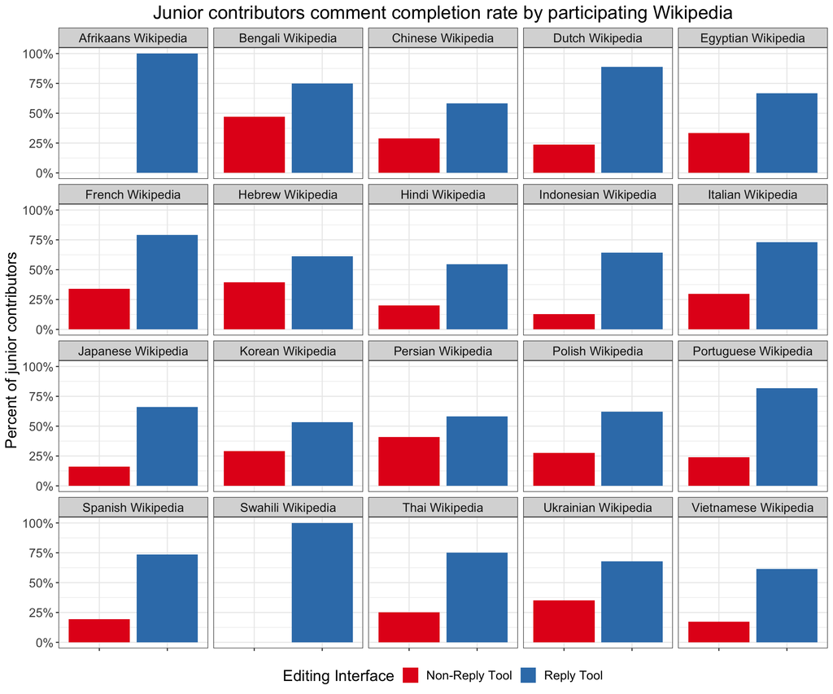

Overall Junior Contributors had a much higher comment completion rate using the reply tool. 72.9% of all Junior Contributors that made a comment attempt were able to successfully publish at least 1 comment with the reply tool, while only 27.6% of all Junior Contributors successfully saved a non-reply tool comment. This represents a 164% observed increase in comment completion rate.

This trend is reflected across each participating Wikipedia as well. Junior Contributors had a higher comment completion rate using the reply tool compared to non-reply tool editor interfaces on every participating Wikipedia. Indonesian, Japanese, Dutch and Spanish Wikipedias saw the highest percent increases in comment completion rates with the reply tool. Notably, we observed the two lowest percent increase in edit completion rate for Persian (42% increase) and Hebrew Wikipedias (55%). These are both right-to-left languages, which might impact the reply tool experience and workflows for contributors on these projects.

## Modeling the impact of the reply tool

We next explored different models to correctly infer the impact of the reply tool on whether a comment was completed or not and account for the random effects by the user and wiki.

We first started with just a standard linear regression where use of the reply tool is the only predictor. In this case, we used a logistic regression model as the outcome (edit complete or not complete) is a binary variable. This model treats all edit attempts as independent and identically distributed and does not account from the effect of the user on the success probability of an edit.

| **Characteristic** | **log(OR)**<sup>1</sup> | **95% CI**<sup>1</sup> | **p-value** |
| --- | --- | --- | --- |
| (Intercept) | -1.0 | -1.1, -0.84 | <0.001 |
| Using reply tool | 2.0 | 1.8, 2.1 | <0.001 |

<sup>*1*</sup> OR = Odds Ratio, CI = Confidence Interval

Since the model parameters are on the log-odds scale, we need to take the exponentiation of the effect (exp(β<sub>1</sub>)) to determine the multiplicative effect on the odds of a Junior Contributor successfully publishing at least 1 comment.

The estimates provided by this model indicate that the odds of a Junior Contributors publishing a comment are multiplied by 7.39 when using the new reply tool; however, this does not take into account the effects of the user and the Wikipedia on comment completion rates.

Comment attempts completed on the same Wikipedia and by the users on that Wikipedia are related to each other. Therefore, we can more accurately infer the impact of the reply tool by incorporating the effects of the user and wiki into the model.

We used a [Bayesian Hierarchical regression model](https://en.wikipedia.org/wiki/Bayesian_hierarchical_modeling) to model this structure since comment attempts in our observed dataset are grouped by user and Wikipedia. In this model, the user and Wikipedia are random effects and whether the reply tool was used is the fixed effect or predictor variable. A Bayesian approach was used so that we can reason about the parameters (and other quantities) probabilistically.

Posterior summary of model parameters

|  | Point Estimate | 95% CI<sup>1</sup> |
| --- | --- | --- |
| Parameter |  |  |
| (Intercept) | −1.048 | (−1.269, −0.830) |
| Using reply tool | 1.981 | (1.778, 2.255) |
| Function of parameter(s) |  |  |
| Multiplicative effect on odds | 7.250 | (5.919, 9.532) |
| Maximum Lift | 49.5%<sup>2</sup> | (44.5%, 56.4%) |
| Average lift | 45.7%<sup>3</sup> | (41.6%, 51.0%) |

<sup>*1*</sup> CI: Credible Interval <sup>*2*</sup> Maximum lift calculated using the divide-by-4-rule <sup>*3*</sup> Average lift = Pr(Success|Reply Tool) - Pr(Success|Non-Reply Tool) = logit<sup>-1</sup>(β<sub>0</sub> + β<sub>1</sub>) - logit<sup>-1</sup>(β<sub>0</sub>)

# Comment Completion Rate Across all Contributor Experience Levels [IN PROGRESS]

As the purpose of this test, we primarily focused on determining if the reply tool had an impact on Junior Contributors’ comment completion rate; however, we also reviewed the reply tool impact across all contributors’ comment completion rates to provide insight into differences due to experience level.

## Overall Comment Completion Rate

All Contributors Comment Completion Rate

Across all Participating Wikipedias

| editor_interface | n_users | n_users_completed | completion_rate<sup>1</sup> |
| --- | --- | --- | --- |
| Non-Reply Tool | 2650 | 1369 | 51.7% |
| Reply Tool | 2040 | 1406 | 68.9% |

<sup>*1*</sup> Defined as percent of contributors that make a comment attempt and publish at least 1 comment.

## Participating Wiki Comment Completion Rate

All Contributors Comment Completion Rate By Participating Wikipedia

| wiki | editor_interface | n_users | n_users_completed | completion_rate<sup>1</sup> |
| --- | --- | --- | --- | --- |
| Afrikaans Wikipedia | Non-Reply Tool | 4 | 3 | 75% |
| Afrikaans Wikipedia | Reply Tool | 1 | 1 | 100% |
| Bengali Wikipedia | Non-Reply Tool | 28 | 17 | 60.7% |
| Bengali Wikipedia | Reply Tool | 18 | 14 | 77.8% |
| Chinese Wikipedia | Non-Reply Tool | 122 | 60 | 49.2% |
| Chinese Wikipedia | Reply Tool | 83 | 46 | 55.4% |
| Dutch Wikipedia | Non-Reply Tool | 109 | 56 | 51.4% |
| Dutch Wikipedia | Reply Tool | 77 | 65 | 84.4% |
| Egyptian Wikipedia | Non-Reply Tool | 8 | 2 | 25% |
| Egyptian Wikipedia | Reply Tool | 3 | 2 | 66.7% |
| French Wikipedia | Non-Reply Tool | 394 | 229 | 58.1% |
| French Wikipedia | Reply Tool | 422 | 327 | 77.5% |
| Hebrew Wikipedia | Non-Reply Tool | 199 | 119 | 59.8% |
| Hebrew Wikipedia | Reply Tool | 104 | 62 | 59.6% |
| Hindi Wikipedia | Non-Reply Tool | 27 | 7 | 25.9% |
| Hindi Wikipedia | Reply Tool | 13 | 6 | 46.2% |
| Indonesian Wikipedia | Non-Reply Tool | 64 | 16 | 25% |
| Indonesian Wikipedia | Reply Tool | 25 | 15 | 60% |
| Italian Wikipedia | Non-Reply Tool | 398 | 222 | 55.8% |
| Italian Wikipedia | Reply Tool | 355 | 240 | 67.6% |
| Japanese Wikipedia | Non-Reply Tool | 218 | 98 | 45% |
| Japanese Wikipedia | Reply Tool | 121 | 67 | 55.4% |
| Korean Wikipedia | Non-Reply Tool | 41 | 17 | 41.5% |
| Korean Wikipedia | Reply Tool | 19 | 9 | 47.4% |
| Persian Wikipedia | Non-Reply Tool | 134 | 71 | 53% |
| Persian Wikipedia | Reply Tool | 89 | 51 | 57.3% |
| Polish Wikipedia | Non-Reply Tool | 148 | 79 | 53.4% |
| Polish Wikipedia | Reply Tool | 126 | 72 | 57.1% |
| Portuguese Wikipedia | Non-Reply Tool | 144 | 66 | 45.8% |
| Portuguese Wikipedia | Reply Tool | 179 | 144 | 80.4% |
| Spanish Wikipedia | Non-Reply Tool | 423 | 198 | 46.8% |
| Spanish Wikipedia | Reply Tool | 322 | 230 | 71.4% |
| Swahili Wikipedia | Non-Reply Tool | 3 | 2 | 66.7% |
| Swahili Wikipedia | Reply Tool | 1 | 1 | 100% |
| Thai Wikipedia | Non-Reply Tool | 19 | 10 | 52.6% |
| Thai Wikipedia | Reply Tool | 9 | 7 | 77.8% |
| Ukrainian Wikipedia | Non-Reply Tool | 114 | 75 | 65.8% |
| Ukrainian Wikipedia | Reply Tool | 50 | 35 | 70% |
| Vietnamese Wikipedia | Non-Reply Tool | 53 | 22 | 41.5% |
| Vietnamese Wikipedia | Reply Tool | 23 | 12 | 52.2% |

<sup>*1*</sup> Defined as percent of contributors that make a comment attempt and publish at least 1 comment.

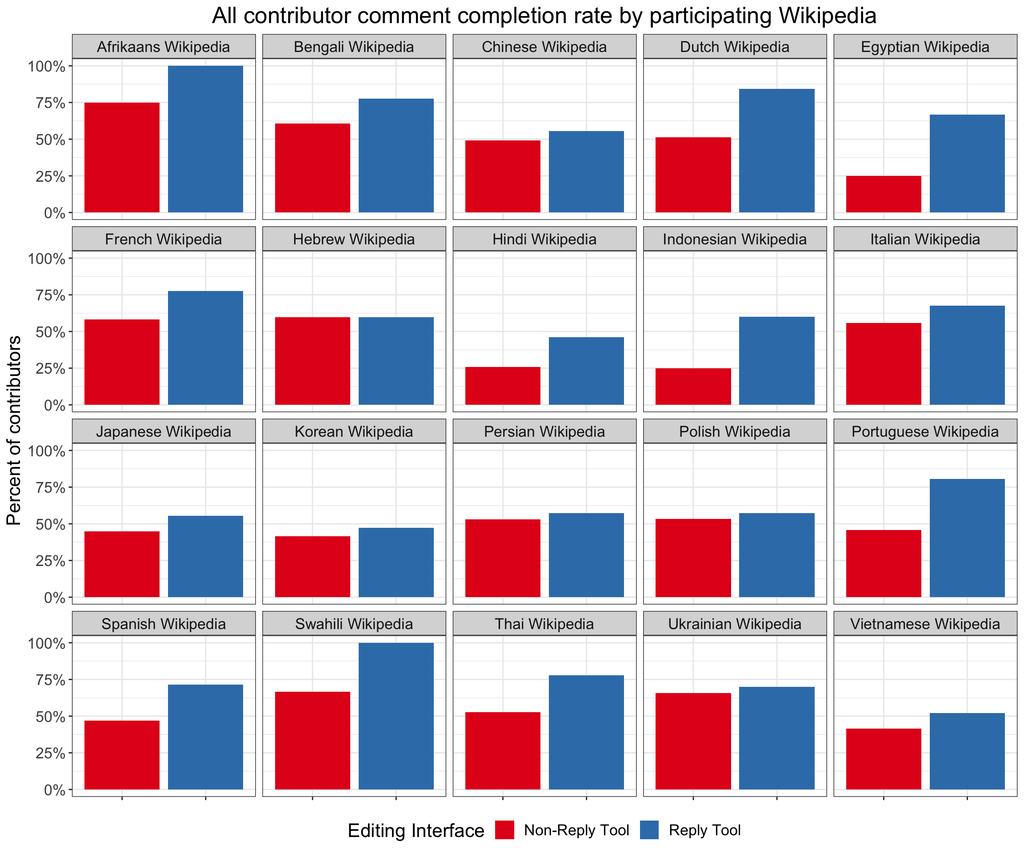

Based on this observed data, it appears that experience level has a small impact on the ability of contributors to publish a comment using the reply tool but a large impact on the ability of contributors able to publish a comment using non-reply tool editing interfaces.

Reviewing each participating Wikipedia individually, we found that a higher percent of contributors across all experience levels were able to successfully publish at least 1 comment using the reply tool except for Hebrew Wikipedia, which had only a very slightly smaller percentage of contributors that were able to publish an edit using the repoy tool (-0.3% change).

Note: There were very few AB test events recorded for Swahili, Afrikaans, and Egyptian Wikipedia and no recorded AB test events for Amharic and Oromo Wikipedia. As a result, we are not able to conclude any effects from the reply tool on these specific Wikis.

## Modeling the impact of the reply tool

[output not shown]

| **Characteristic** | **log(OR)**<sup>1</sup> | **95% CI**<sup>1</sup> | **p-value** |
| --- | --- | --- | --- |
| (Intercept) | 0.05 | -0.02, 0.13 | 0.2 |
| reply_tool_used | 0.73 | 0.61, 0.85 | <0.001 |

<sup>*1*</sup> OR = Odds Ratio, CI = Confidence Interval

The estimates provided by the standard linear regression model indicate that the odds of a Contributor publishing at least one successful cimment are multiplied by 2.08 when using the reply tool.

We then used the Bayesian Hierachical Regression Model to account for the effects the user or their experience level on edit completion rates.

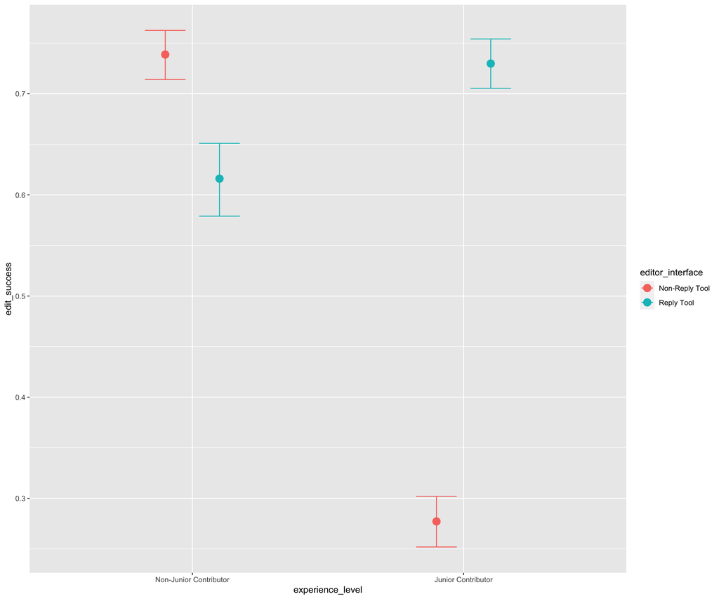

The above plot shows the predicted effects of the two interaction variables that impact a contributors’ likelihood to successfully publish at least 1 comment after making an attempt: (1) the editor interface used to make the comment and (2) the contributors’ experience level based on their cumulative edits.

The plot indicates that experience level has a signficant impact on comment completion rate for comments made with the non-reply tool.

# Guardrail Analysis

We also wanted to ensure that the reply tool did not result in an increase in the number of distruptive edits being made to talk pages.

To evaluate any disruption caused by the reply tool, we determined the percent of comments made to talk pages that were reverted within 48 hours and the percent of contributors blocked after makeing a comment to a talk page.

## Comment Revert Rate for Junior Contributors

### Methodology

For this analysis, we reviewed data recorded in [mediawiki_history](https://wikitech.wikimedia.org/wiki/Analytics/Data_Lake/Edits/MediaWiki_history) to identify the percent comments posted by the reply tool (identified by the revision tag: `discussiontools-reply`) on talk pages that are reverted within 48 hours [1]. We compared the revert rate for comments published using the reply tool to the revert rate for comments made by non-reply tool editing interfaces during the same time frame.

[1] 48 hours is a common cutoff, as research suggests that, at least for the English Wikipedia, nearly all reverts take place within 48 hours

The reviewed data excludes wikitext edits to create new pages and edits to start new topics using the [new discussion tool](https://www.mediawiki.org/wiki/Talk_pages_project/New_discussion).

## Overall revert rate by editor type

Overall Junior Contributors Comment Revert Rate

Across all Participating Wikipedias

| editing_interface | total_reverts | total_comments | revert_rate<sup>1</sup> |
| --- | --- | --- | --- |
| Non-Reply Tool | 1580 | 13891 | 11.37 % |
| Reply Tool | 27 | 1638 | 1.65 % |

<sup>*1*</sup> Defined as percent of comments reverted within 48 hours.

Overall, across all paticipating Wikipedia, comments made by Junior Contributors with the reply tool have a significantly lower revert rate (1.65%) compared to comments made with non-reply tool editing interfaces (11.37%).

## Revert Rate by Wiki

Junior Contributors Comment Revert Rate By Participating Wikipedia

| wiki | editing_interface | total_reverts | total_comments | revert_rate<sup>1</sup> |
| --- | --- | --- | --- | --- |
| Afrikaans Wikipedia | Non-Reply Tool | 0 | 20 | 0 % |
| Afrikaans Wikipedia | Reply Tool | 0 | 4 | 0 % |
| Amharic Wikipedia | Non-Reply Tool | 0 | 2 | 0 % |
| Bengali Wikipedia | Non-Reply Tool | 36 | 474 | 7.59 % |
| Bengali Wikipedia | Reply Tool | 1 | 3 | 33.33 % |
| Chinese Wikipedia | Non-Reply Tool | 42 | 532 | 7.89 % |
| Chinese Wikipedia | Reply Tool | 2 | 33 | 6.06 % |
| Dutch Wikipedia | Non-Reply Tool | 15 | 339 | 4.42 % |
| Dutch Wikipedia | Reply Tool | 1 | 92 | 1.09 % |
| Egyptian Wikipedia | Non-Reply Tool | 2 | 34 | 5.88 % |
| Egyptian Wikipedia | Reply Tool | 0 | 1 | 0 % |
| French Wikipedia | Non-Reply Tool | 75 | 2222 | 3.38 % |
| French Wikipedia | Reply Tool | 7 | 364 | 1.92 % |
| Hebrew Wikipedia | Non-Reply Tool | 127 | 823 | 15.43 % |
| Hebrew Wikipedia | Reply Tool | 0 | 85 | 0 % |
| Hindi Wikipedia | Non-Reply Tool | 129 | 419 | 30.79 % |
| Hindi Wikipedia | Reply Tool | 0 | 14 | 0 % |
| Indonesian Wikipedia | Non-Reply Tool | 25 | 253 | 9.88 % |
| Indonesian Wikipedia | Reply Tool | 0 | 14 | 0 % |
| Italian Wikipedia | Non-Reply Tool | 82 | 1340 | 6.12 % |
| Italian Wikipedia | Reply Tool | 2 | 286 | 0.7 % |
| Japanese Wikipedia | Non-Reply Tool | 152 | 1004 | 15.14 % |
| Japanese Wikipedia | Reply Tool | 2 | 73 | 2.74 % |
| Korean Wikipedia | Non-Reply Tool | 113 | 698 | 16.19 % |
| Korean Wikipedia | Reply Tool | 0 | 18 | 0 % |
| Persian Wikipedia | Non-Reply Tool | 196 | 1989 | 9.85 % |
| Persian Wikipedia | Reply Tool | 0 | 64 | 0 % |
| Polish Wikipedia | Non-Reply Tool | 52 | 512 | 10.16 % |
| Polish Wikipedia | Reply Tool | 1 | 91 | 1.1 % |
| Portuguese Wikipedia | Non-Reply Tool | 225 | 1047 | 21.49 % |
| Portuguese Wikipedia | Reply Tool | 2 | 224 | 0.89 % |
| Spanish Wikipedia | Non-Reply Tool | 242 | 1533 | 15.79 % |
| Spanish Wikipedia | Reply Tool | 9 | 227 | 3.96 % |
| Swahili Wikipedia | Non-Reply Tool | 0 | 5 | 0 % |
| Swahili Wikipedia | Reply Tool | 0 | 1 | 0 % |
| Thai Wikipedia | Non-Reply Tool | 7 | 84 | 8.33 % |
| Thai Wikipedia | Reply Tool | 0 | 8 | 0 % |
| Ukrainian Wikipedia | Non-Reply Tool | 44 | 335 | 13.13 % |
| Ukrainian Wikipedia | Reply Tool | 0 | 25 | 0 % |
| Vietnamese Wikipedia | Non-Reply Tool | 16 | 226 | 7.08 % |
| Vietnamese Wikipedia | Reply Tool | 0 | 11 | 0 % |

<sup>*1*</sup> Defined as percent of comments reverted within 48 hours.

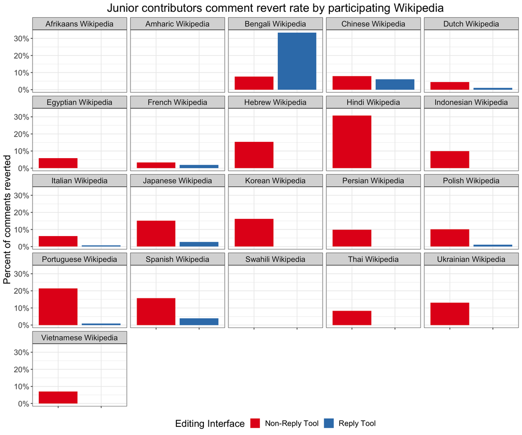

Note: No published talk page comments were recorded for Oromo Wikipedia during the duration of the AB test and no reverts were recorded for Afrikanns, Amharic or Swahili Wikipedias. Additionally, Bengali and Egyptian Wikipedia did not have enough comments recoded to accurately determine a revert rate representative of the populaton.

## Revert Rate By Experience Level

Contributors Comment Revert Rate By Experience Level

| editing_interface | experience_level | total_reverts | total_comments | revert_rate<sup>1</sup> |
| --- | --- | --- | --- | --- |
| Non-Reply Tool | Non-Junior Contributor | 2569 | 156417 | 1.64 % |
| Non-Reply Tool | Junior Contributor | 1580 | 13891 | 11.37 % |
| Reply Tool | Non-Junior Contributor | 83 | 3940 | 2.11 % |
| Reply Tool | Junior Contributor | 27 | 1638 | 1.65 % |

<sup>*1*</sup> Defined as percent of comments reverted within 48 hours.

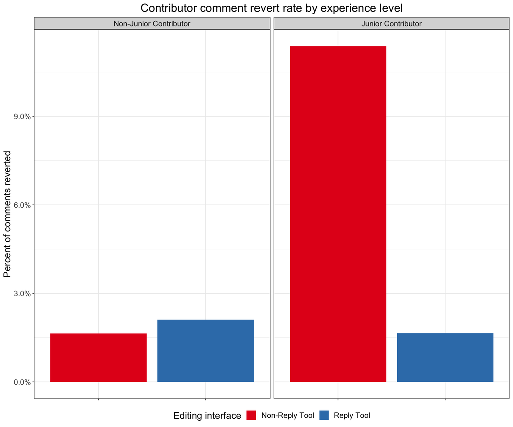

## Percent of Junior Contributors blocked after posting a comment

We also reviewed the number of Junior Contributors blocked after posting a comment using the reply tool.

Data comes from the mediawiki_user_history table. All block events identified in the data by `caused_by_event_type = "alterblocks"`. The data includes any Contributors that was blocked after posting a comment; however, we do not know if they were blocked specifically due to the comment posted. Data is also currently limited to dates of the AB test. Users may have been blocked following this analysis.

## Blocked Users Overall

Junior Contributors Blocked After Publishing a Comment

| editing_interface | total_blocked_users | total_users | pct_blocked |
| --- | --- | --- | --- |
| Non-Reply Tool | 82 | 5295 | 1.55 % |
| Reply Tool | 15 | 829 | 1.81 % |

## Blocked Users By Wiki

Junior Contributors Blocked After Publishing a Comment By Participating Wikipedia

| wiki | editing_interface | total_blocked_users | total_users | pct_blocked |
| --- | --- | --- | --- | --- |
| Afrikaans Wikipedia | Non-Reply Tool | 0 | 11 | 0 % |
| Afrikaans Wikipedia | Reply Tool | 0 | 1 | 0 % |
| Amharic Wikipedia | Non-Reply Tool | 0 | 2 | 0 % |
| Bengali Wikipedia | Non-Reply Tool | 0 | 153 | 0 % |
| Bengali Wikipedia | Reply Tool | 0 | 3 | 0 % |
| Chinese Wikipedia | Non-Reply Tool | 3 | 203 | 1.48 % |
| Chinese Wikipedia | Reply Tool | 0 | 23 | 0 % |
| Dutch Wikipedia | Non-Reply Tool | 1 | 119 | 0.84 % |
| Dutch Wikipedia | Reply Tool | 0 | 35 | 0 % |
| Egyptian Wikipedia | Non-Reply Tool | 0 | 20 | 0 % |
| Egyptian Wikipedia | Reply Tool | 0 | 1 | 0 % |
| French Wikipedia | Non-Reply Tool | 6 | 976 | 0.61 % |
| French Wikipedia | Reply Tool | 3 | 217 | 1.38 % |
| Hebrew Wikipedia | Non-Reply Tool | 6 | 232 | 2.59 % |
| Hebrew Wikipedia | Reply Tool | 0 | 31 | 0 % |
| Hindi Wikipedia | Non-Reply Tool | 1 | 213 | 0.47 % |
| Hindi Wikipedia | Reply Tool | 0 | 7 | 0 % |
| Indonesian Wikipedia | Non-Reply Tool | 3 | 126 | 2.38 % |
| Indonesian Wikipedia | Reply Tool | 0 | 10 | 0 % |
| Italian Wikipedia | Non-Reply Tool | 7 | 436 | 1.61 % |
| Italian Wikipedia | Reply Tool | 3 | 135 | 2.22 % |
| Japanese Wikipedia | Non-Reply Tool | 7 | 297 | 2.36 % |
| Japanese Wikipedia | Reply Tool | 0 | 20 | 0 % |
| Korean Wikipedia | Non-Reply Tool | 1 | 150 | 0.67 % |
| Korean Wikipedia | Reply Tool | 0 | 5 | 0 % |
| Persian Wikipedia | Non-Reply Tool | 17 | 687 | 2.47 % |
| Persian Wikipedia | Reply Tool | 1 | 34 | 2.94 % |
| Polish Wikipedia | Non-Reply Tool | 6 | 209 | 2.87 % |
| Polish Wikipedia | Reply Tool | 1 | 42 | 2.38 % |
| Portuguese Wikipedia | Non-Reply Tool | 16 | 445 | 3.6 % |
| Portuguese Wikipedia | Reply Tool | 3 | 102 | 2.94 % |
| Spanish Wikipedia | Non-Reply Tool | 4 | 694 | 0.58 % |
| Spanish Wikipedia | Reply Tool | 2 | 136 | 1.47 % |
| Swahili Wikipedia | Non-Reply Tool | 0 | 3 | 0 % |
| Swahili Wikipedia | Reply Tool | 0 | 1 | 0 % |
| Thai Wikipedia | Non-Reply Tool | 0 | 46 | 0 % |
| Thai Wikipedia | Reply Tool | 0 | 4 | 0 % |
| Ukrainian Wikipedia | Non-Reply Tool | 2 | 141 | 1.42 % |
| Ukrainian Wikipedia | Reply Tool | 2 | 16 | 12.5 % |
| Vietnamese Wikipedia | Non-Reply Tool | 2 | 132 | 1.52 % |
| Vietnamese Wikipedia | Reply Tool | 0 | 6 | 0 % |

Overall, across all participating Wikipedias, 1.81% of reply tool Junior Contributors were blocked after posting a comment with the reply tool, which is not signficantly different than the percent of non-reply tool Junior Contributors that were blocked during the same timeframe.

Under 3% of all Junior Contributors were blocked on all participating Wikipedias with the exception of Ukranian Wikipedia and Portuguese Wikipedia. 12.5% of Ukranian Wikipedia Junior Contributors reply tool users were blocked; however, comments were only posted by 16 users on this project during the reviewed timeframe and we confirmed that the two users blocked were the same ones blocked after using the non-reply tool as well.

## Blocked Users By Experience Level

Contributors Blocked After Publishing a Comment By Experience Level

| editing_interface | experience_level | total_blocked_users | total_users | pct_blocked_reply_users |
| --- | --- | --- | --- | --- |
| Non-Reply Tool | Non-Junior Contributor | 67 | 7056 | 0.95 |
| Non-Reply Tool | Junior Contributor | 82 | 5295 | 1.55 |
| Reply Tool | Non-Junior Contributor | 10 | 791 | 1.26 |
| Reply Tool | Junior Contributor | 15 | 829 | 1.81 |

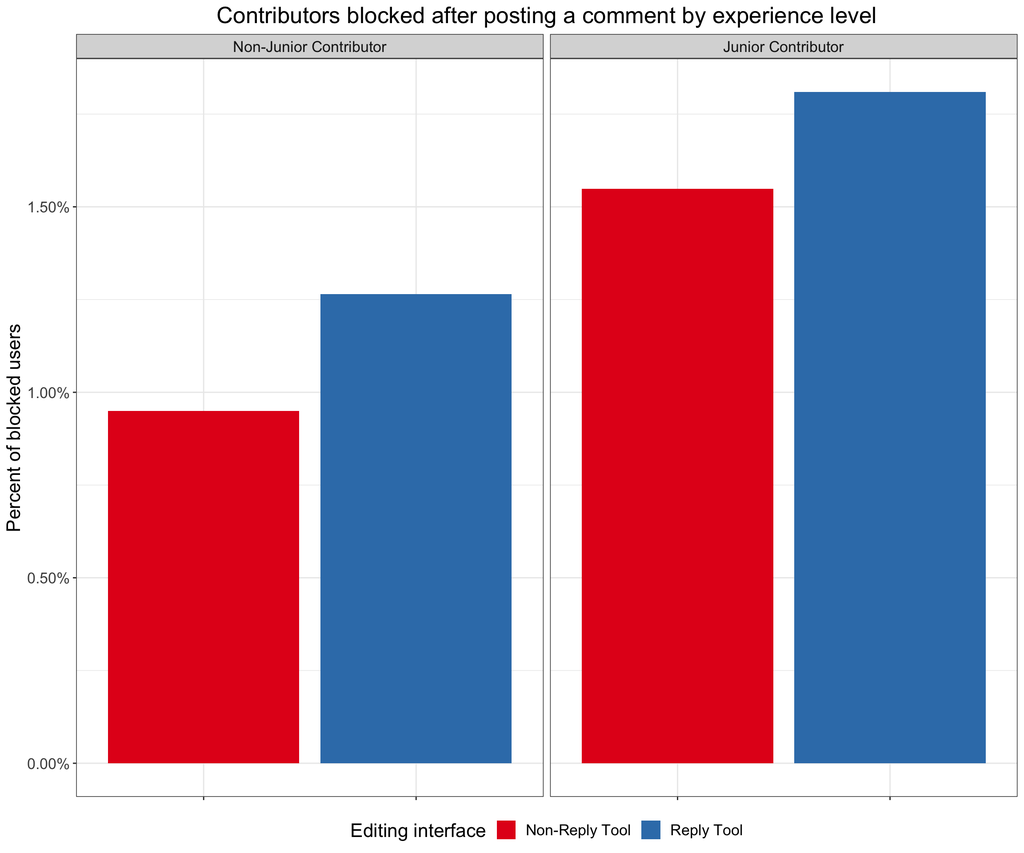